# Práctica: genómica del cáncer de mama antes y después del tratamiento preoperatorio

Magíster en Genética — Universidad de Chile · Sesión práctica guiada (90 min)

Luis Zapata Ortiz

19-11-2026

> **Datos reales anonimizados — uso docente exclusivo.** Los datos provienen de la cohorte del ensayo PRADA (The Institute of Cancer Research, Londres) y se entregan solo para esta práctica. **No los redistribuyas ni los subas a repositorios públicos.** Los pacientes se identifican como `PAC01`–`PAC08`.

# 1 Objetivos, requisitos y cronograma

**Al terminar la práctica podrás:**

1. Leer un VCF somático tumor–normal en R y controlar su calidad (profundidad, recuentos de alelos, VAF).
2. Comparar dos momentos de un mismo tumor y distinguir **persistencia clonal real** de **ausencia por falta de potencia de detección**.
3. Relacionar VAF, pureza y número de copias con la fracción de células cancerosas (CCF), y explicitar los supuestos.
4. Calcular TMB con una definición explícita y explorar espectros mutacionales, separando **espectro observado** de **atribución a firmas**.
5. Describir el microambiente inmune con firmas de expresión y repertorios TCR, reconociendo los confusores.
6. Integrar los resultados con la clínica y con los biomarcadores de inmunoterapia (PD-L1, TMB, MSI), usando bases de datos públicas.

**Requisitos:** R ≥ 4.2 con `ggplot2`, `ggsci`, `patchwork` y `nnls`. Todo el código se ejecuta en menos de un minuto.

```r
## Ejecutar UNA vez si falta algún paquete
install.packages(c("ggplot2", "ggsci", "patchwork", "nnls", "rmarkdown"))
```

| Minutos | Bloque | Figura |
| --- | --- | --- |
| 0–8 | 0. El caso y los datos | — |
| 8–23 | 1. Inspección y control de calidad del VCF | Fig. 1 |
| 23–43 | 2. Diagnóstico vs cirugía: ¿qué mutaciones persisten? | Fig. 2 |
| 43–61 | 3. Carga mutacional, espectro y firmas; número de copias y CCF | Fig. 3, Fig. 4 |
| 61–75 | 4. Microambiente inmune y repertorio TCR | Fig. 5, Fig. 6 |
| 75–87 | 5. Caso integrador y bases de datos | Tabla |
| 87–90 | Cierre | — |

```r
library(ggplot2)
library(ggsci)       # paleta NPG (scale_color_npg / scale_fill_npg)
library(patchwork)   # combinar paneles
source("scripts/funciones_practica.R")   # leer_vcf(), calcular_ccf(), contar_sbs96(), ...
theme_set(theme_bw(base_size = 11))
dir.create("figuras", showWarnings = FALSE)
```

# 2 Bloque 0 — El caso y los datos (8 min)

**Diseño.** Ocho pacientes con cáncer de mama recibieron **quimioterapia y radioterapia preoperatorias** (brazo PRADA). De cada paciente hay:

- **D** — biopsia diagnóstica, antes del tratamiento;
- **M** — pieza de mastectomía, después del tratamiento;
- **N** — sangre (normal germinal), usada para llamar variantes **somáticas**.

Se secuenció el exoma completo (**WES**) sobre el genoma de referencia **GRCh38**. Las variantes se llamaron con nextNEOpi (Mutect2 más un segundo llamador, Strelka o VarScan) y se anotaron con VEP.

**Caso guía: `PAC01`**, un carcinoma **triple negativo (TNBC)**, T4, con ganglios positivos y **sin respuesta patológica completa (no pCR)**.

```r
clin <- read.delim("data/clinica_docente.tsv")
clin
```

| paciente | momento | subtipo | estadio_T | ganglios | grado | pureza_patologia | sTIL | pCR | respuesta | tratamiento |
| --- | --- | --- | --- | --- | --- | --- | --- | --- | --- | --- |
| PAC01 | D | TNBC | 4 | Yes | 3 | 0.339629 | 5 | No | Non-responder | Quimioterapia + radioterapia preoperatoria (brazo PRADA) |
| PAC01 | M | TNBC | 4 | Yes | 3 | 0.050902 | 2 | No | Non-responder | Quimioterapia + radioterapia preoperatoria (brazo PRADA) |
| PAC02 | D | HER2+ | 4 | Yes | 3 | 0.358077 | 50 | Yes | Responder | Quimioterapia + radioterapia preoperatoria (brazo PRADA) |
| PAC02 | M | HER2+ | 4 | Yes | 3 | 0.000000 | 1 | Yes | Responder | Quimioterapia + radioterapia preoperatoria (brazo PRADA) |
| PAC03 | D | HR+ | 2 | Yes | 3 | 0.411598 | 25 | Yes | Responder | Quimioterapia + radioterapia preoperatoria (brazo PRADA) |
| PAC03 | M | HR+ | 2 | Yes | 3 | 0.003054 | 1 | Yes | Responder | Quimioterapia + radioterapia preoperatoria (brazo PRADA) |
| PAC04 | D | HR+ | 3 | No | 2 | 0.255682 | 4 | No | Non-responder | Quimioterapia + radioterapia preoperatoria (brazo PRADA) |
| PAC04 | M | HR+ | 3 | No | 2 | 0.047802 | 2 | No | Non-responder | Quimioterapia + radioterapia preoperatoria (brazo PRADA) |
| PAC05 | D | HR+ | 3 | Yes | 2 | 0.206766 | 15 | No | Non-responder | Quimioterapia + radioterapia preoperatoria (brazo PRADA) |
| PAC05 | M | HR+ | 3 | Yes | 2 | 0.039723 | 5 | No | Non-responder | Quimioterapia + radioterapia preoperatoria (brazo PRADA) |
| PAC06 | D | HR+ | 2 | Yes | 2 | 0.119576 | 20 | No | Non-responder | Quimioterapia + radioterapia preoperatoria (brazo PRADA) |
| PAC06 | M | HR+ | 2 | Yes | 2 | 0.000000 | 2 | No | Non-responder | Quimioterapia + radioterapia preoperatoria (brazo PRADA) |
| PAC07 | D | HER2+ | 3 | Yes | 2 | 0.360648 | 15 | Yes | Responder | Quimioterapia + radioterapia preoperatoria (brazo PRADA) |
| PAC07 | M | HER2+ | 3 | Yes | 2 | 0.000000 | 1 | Yes | Responder | Quimioterapia + radioterapia preoperatoria (brazo PRADA) |
| PAC08 | D | HER2+ | 3 | Yes | 3 | 0.205158 | 1 | Yes | Responder | Quimioterapia + radioterapia preoperatoria (brazo PRADA) |
| PAC08 | M | HER2+ | 3 | Yes | 3 | 0.001295 | 2 | Yes | Responder | Quimioterapia + radioterapia preoperatoria (brazo PRADA) |

> **Pregunta 0.1.** ¿Por qué la pureza (fracción de células tumorales) de las muestras **M** es tan baja, y en algunos casos 0? ¿Qué esperas encontrar en el VCF de una muestra M con 0 % de tumor?

| Archivo | Contenido |
| --- | --- |
| `data/vcf/PACxx_{D,M}.somatic.vcf.gz` | Variantes somáticas (SNV e indels) con columnas NORMAL y TUMOR |
| `data/recuentos_forzados_snv.tsv` | Lecturas REF/ALT en D **y** M en todas las SNV del paciente (*pileup* forzado) |
| `data/cnv/segmentos_sequenza.tsv` | Número de copias total, mayor y menor (Sequenza) |
| `data/pureza_y_tmb_nextneopi.tsv` | Pureza estimada por patología, Sequenza y ASCAT; territorio exónico evaluable |
| `data/sv_manta_pass.tsv`, `data/fusiones_arriba.tsv` | Variantes estructurales (Manta, ADN) y fusiones (Arriba, ARN) |
| `data/expresion_inmune_tpm.tsv` | Expresión (TPM) de 52 genes inmunes y de linaje |
| `data/tcr/PACxx-T*.tsv` | Clonotipos TCRβ (CDR3) y sus recuentos |
| `data/cosmic_sbs_v3.4_GRCh38.tsv` | Firmas mutacionales de referencia COSMIC v3.4 |

# 3 Bloque 1 — Inspección y control de calidad (15 min)

## 3.1 Mirar el VCF crudo

```r
lineas <- readLines("data/vcf/PAC01_D.somatic.vcf.gz")
cat(head(grep("^##", lineas, value = TRUE), 6), sep = "\n")
```

```
## ##fileformat=VCFv4.2
## ##source=nextNEOpi_v1.4_Mutect2_alta_confianza(PASS,_confirmado_por_>=2_llamadores)+VEP
## ##reference=GRCh38 (GRCh38.d1.vd1)
## ##paciente=PAC01
## ##momento=D_biopsia_diagnostica_pretratamiento
## ##datos=REALES_ANONIMIZADOS_cohorte_PRADA_ICR_uso_docente_exclusivo_NO_REDISTRIBUIR
```

```r
cat(grep("^#CHROM", lineas, value = TRUE), lineas[!startsWith(lineas, "#")][1], sep = "\n")
```

```
## #CHROM   POS ID  REF ALT QUAL    FILTER  INFO    FORMAT  NORMAL  TUMOR
## chr1 1399006 .   G   A   .   PASS    GENE=CCNL2;CONSEQUENCE=intron_variant;IMPACT=MODIFIER;HGVSc=c.288+13C>T;HGVSp=.;TRINUC=GGC;CALLERS=M2,ST    GT:AD:DP:AF 0/0:39,1:40:0.025   0/1:34,5:39:0.128
```

> **Pregunta 1.1.** En la primera variante, ¿cuántas lecturas apoyan el alelo alternativo en el **tumor** y cuántas en el **normal**? ¿Por qué es importante que el normal tenga casi 0 lecturas alternativas?

## 3.2 Leer D y M y calcular la VAF

$$\text{VAF} = \frac{\text{lecturas
ALT}}{\text{lecturas REF} + \text{lecturas ALT}}$$

```r
D <- leer_vcf("data/vcf/PAC01_D.somatic.vcf.gz"); D$momento <- "D (diagnóstico)"
M <- leer_vcf("data/vcf/PAC01_M.somatic.vcf.gz"); M$momento <- "M (cirugía)"
dm <- rbind(D, M)
## Resumen por muestra
aggregate(cbind(vaf, t_dp, n_dp) ~ momento, data = dm, FUN = median)
```

| momento | vaf | t_dp | n_dp |
| --- | --- | --- | --- |
| D (diagnóstico) | 0.0952381 | 66 | 102 |
| M (cirugía) | 0.0571447 | 93 | 75 |

```r
table(dm$momento, dm$tipo)
```

```
##
##                   INDEL SNV
##   D (diagnóstico)     2 257
##   M (cirugía)         1 141
```

```r
## Control: lecturas alternativas en el normal
summary(dm$n_alt / dm$n_dp)
```

```
##      Min.   1st Qu.    Median      Mean   3rd Qu.      Max.
## 0.0000000 0.0000000 0.0000000 0.0006276 0.0000000 0.0338983
```

## 3.3 Figura 1 — Profundidad, VAF y artefactos

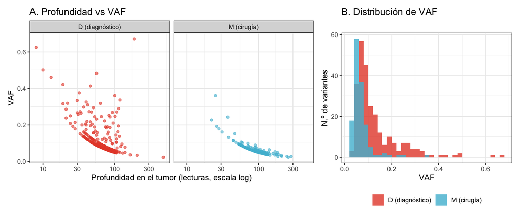

```r
f1a <- ggplot(dm, aes(t_dp, vaf, color = momento)) +
  geom_point(alpha = 0.6, size = 1.4) + scale_x_log10() +
  facet_wrap(~momento) + scale_color_npg(guide = "none") +
  labs(x = "Profundidad en el tumor (lecturas, escala log)", y = "VAF", title = "A. Profundidad vs VAF")
f1b <- ggplot(dm, aes(vaf, fill = momento)) +
  geom_histogram(binwidth = 0.02, boundary = 0, alpha = 0.8, position = "identity") +
  scale_fill_npg() + labs(x = "VAF", y = "N.º de variantes", fill = NULL, title = "B. Distribución de VAF") +
  theme(legend.position = "bottom")
fig1 <- f1a + f1b + plot_layout(widths = c(2, 1.2))
fig1
```

```r
ggsave("figuras/Fig1_QC_VAF_PAC01.png", fig1, width = 10, dpi = 300, height = 4.2)
```

> **Pregunta 1.2.** Si una mutación clonal y heterocigota está en un tumor diploide con pureza $p$, su VAF esperada es $p/2$. Con la pureza patológica de D (0.34), ¿qué VAF esperarías? ¿Coincide con el histograma?

> **Pregunta 1.3.** ¿Por qué la muestra M tiene casi todas sus variantes con VAF < 0,1? Plantea al menos dos explicaciones: una biológica y una técnica.

# 4 Bloque 2 — Diagnóstico vs cirugía: ¿qué mutaciones persisten? (20 min)

## 4.1 Compartidas y privadas según el llamador

```r
D$clave <- paste(D$chrom, D$pos, D$ref, D$alt); M$clave <- paste(M$chrom, M$pos, M$ref, M$alt)
c(solo_D = sum(!D$clave %in% M$clave), compartidas = sum(D$clave %in% M$clave), solo_M = sum(!M$clave %in% D$clave))
```

```
##      solo_D compartidas      solo_M
##         257           2         140
```

Según el llamador, casi nada se comparte. ¿Significa que el tumor residual es otro tumor? **No necesariamente:** que una mutación no se *llame* no significa que esté *ausente*. Para comprobarlo usamos los **recuentos forzados**: el número de lecturas REF y ALT en **ambas** muestras en cada posición mutada del paciente.

```r
fz <- read.delim("data/recuentos_forzados_snv.tsv")
fz$clave <- paste(fz$chrom, fz$pos, fz$ref, fz$alt)
## Tabla ancha: una fila por mutación de PAC01 con lecturas en D y en M
p1 <- subset(fz, paciente == "PAC01")
anch <- merge(subset(p1, momento == "D"), subset(p1, momento == "M"), by = "clave", suffixes = c("_D", "_M"))
anch$vaf_D <- anch$alt_count_D / anch$depth_D
anch$vaf_M <- anch$alt_count_M / anch$depth_M
anch$llamada <- ifelse(anch$clave %in% D$clave & anch$clave %in% M$clave, "llamada en D y M",
                ifelse(anch$clave %in% D$clave, "llamada solo en D", "llamada solo en M"))
anch$gen <- c(D$gen, M$gen)[match(anch$clave, c(D$clave, M$clave))]
anch$impacto <- c(D$impacto, M$impacto)[match(anch$clave, c(D$clave, M$clave))]
## ¿Cuántas mutaciones de D tienen al menos 1 o al menos 3 lecturas ALT en M?
dD <- subset(anch, llamada != "llamada solo en M")
c(n_mut_D = nrow(dD), con_1_alt_en_M = sum(dD$alt_count_M >= 1), con_3_alt_en_M = sum(dD$alt_count_M >= 3))
```

```
##        n_mut_D con_1_alt_en_M con_3_alt_en_M
##            257             82             13
```

```r
## Los drivers del caso
subset(anch, gen %in% c("TP53", "NF1") & impacto %in% c("HIGH", "MODERATE"), c(gen, alt_count_D, depth_D, alt_count_M, depth_M))
```

|  | gen | alt_count_D | depth_D | alt_count_M | depth_M |
| --- | --- | --- | --- | --- | --- |
| 157 | NF1 | 7 | 35 | 0 | 43 |
| 178 | TP53 | 15 | 58 | 3 | 104 |

## 4.2 Potencia de detección

Si M tiene una pureza de ~5 %, una mutación clonal y heterocigota tendrá una VAF esperada de ~2,5 %. Con una profundidad de 80×, ¿qué probabilidad hay de ver al menos 3 lecturas alternativas?

```r
pur_M <- clin$pureza_patologia[clin$paciente == "PAC01" & clin$momento == "M"]
potencia_deteccion(dp = 80, vaf_esperada = pur_M / 2, k_min = 3)
```

```
## [1] 0.3332003
```

```r
## Potencia media sobre las mutaciones reales de D, usando la profundidad observada en M
mean(potencia_deteccion(dD$depth_M, pur_M / 2, 3))
```

```
## [1] 0.343297
```

## 4.3 Control negativo: las muestras M sin tumor

Tres pacientes tienen **0 % de tumor** en M según patología: `PAC02` y `PAC07` (con pCR) y `PAC06` (sin pCR, clasificado como no respondedor; ¿cómo puede ser? piensa en el muestreo del bloque de patología frente al lecho tumoral). En ellas, las lecturas alternativas en posiciones de D reflejan **ruido técnico** (o células tumorales aisladas que la patología no vio).

```r
cohorte <- do.call(rbind, lapply(sprintf("PAC%02d", 1:8), function(p) {
  d <- leer_vcf(sprintf("data/vcf/%s_D.somatic.vcf.gz", p))
  f <- subset(fz, paciente == p & momento == "M" & clave %in% paste(d$chrom, d$pos, d$ref, d$alt))
  data.frame(paciente = p,
             pureza_M = clin$pureza_patologia[clin$paciente == p & clin$momento == "M"],
             pCR = clin$pCR[clin$paciente == p & clin$momento == "M"],
             frac_alt3_en_M = mean(f$alt_count >= 3),
             llamados_en_M = nrow(leer_vcf(sprintf("data/vcf/%s_M.somatic.vcf.gz", p))))
}))
cohorte
```

| paciente | pureza_M | pCR | frac_alt3_en_M | llamados_en_M |
| --- | --- | --- | --- | --- |
| PAC01 | 0.050902 | No | 0.0505837 | 142 |
| PAC02 | 0.000000 | Yes | 0.0241935 | 188 |
| PAC03 | 0.003054 | Yes | 0.0026667 | 66 |
| PAC04 | 0.047802 | No | 0.0921053 | 139 |
| PAC05 | 0.039723 | No | 0.5349206 | 606 |
| PAC06 | 0.000000 | No | 0.0177515 | 106 |
| PAC07 | 0.000000 | Yes | 0.0743802 | 169 |
| PAC08 | 0.001295 | Yes | 0.0114504 | 364 |

## 4.4 Figura 2 — Persistencia clonal y límites de detección

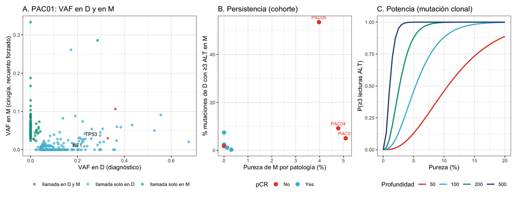

```r
f2a <- ggplot(anch, aes(vaf_D, vaf_M, color = llamada)) +
  geom_point(alpha = 0.7, size = 1.6) +
  geom_text(data = subset(anch, gen %in% c("TP53", "NF1") & impacto %in% c("HIGH", "MODERATE")),
            aes(label = gen), color = "black", vjust = -0.8, size = 3.2) +
  scale_color_npg() +
  labs(x = "VAF en D (diagnóstico)", y = "VAF en M (cirugía, recuento forzado)", color = NULL,
       title = "A. PAC01: VAF en D y en M") + theme(legend.position = "bottom")
f2b <- ggplot(cohorte, aes(pureza_M * 100, frac_alt3_en_M * 100, color = pCR, label = paciente)) +
  geom_point(size = 3) + geom_text(data = subset(cohorte, pureza_M > 0.01), vjust = -0.9, size = 3, show.legend = FALSE) +
  scale_color_npg() +
  labs(x = "Pureza de M por patología (%)", y = "% mutaciones de D con ≥3 ALT en M",
       title = "B. Persistencia (cohorte)") + theme(legend.position = "bottom")
curva <- expand.grid(dp = c(50, 100, 200, 500), pureza = seq(0, 0.2, 0.005))
curva$potencia <- potencia_deteccion(curva$dp, curva$pureza / 2, 3)
f2c <- ggplot(curva, aes(pureza * 100, potencia, color = factor(dp))) + geom_line(linewidth = 1) +
  scale_color_npg() + labs(x = "Pureza (%)", y = "P(≥3 lecturas ALT)", color = "Profundidad",
                           title = "C. Potencia (mutación clonal)") +
  theme(legend.position = "bottom")
fig2 <- f2a + f2b + f2c + plot_layout(widths = c(1.3, 1, 1))
fig2
```

```r
ggsave("figuras/Fig2_persistencia_D_vs_M.png", fig2, width = 13, height = 5, dpi = 300)
```

> **Pregunta 2.1.** ¿TP53 persiste en la muestra residual de PAC01? ¿Cuántas lecturas la apoyan y qué tan convincente es esa evidencia?

> **Pregunta 2.2.** En la Fig. 2B, ¿qué pacientes muestran una persistencia por encima del ruido de fondo que definen las muestras con 0 % de tumor? ¿Por qué PAC05 es tan distinto?

> **Pregunta 2.3.** Las muestras M con 0 % de tumor tienen igualmente entre 106 y 188 variantes “somáticas” llamadas. ¿Qué son? ¿Qué consecuencia tiene esto al interpretar mutaciones “privadas de M” como evolución clonal?

# 5 Bloque 3 — Carga mutacional, espectro, firmas y número de copias (18 min)

## 5.1 Consecuencias funcionales y carga mutacional (TMB)

**Definición de TMB usada aquí** (debe declararse siempre):

- **Mutaciones elegibles:** SNV e indels somáticos codificantes **no sinónimos** (missense, nonsense, frameshift, indels in-frame, sitios de splicing), con VAF ≥ 0,05 y profundidad ≥ 20 en el tumor.
- **Territorio evaluable:** megabases del exoma con cobertura suficiente en tumor **y** normal, calculadas por nextNEOpi para cada muestra (~42–51 Mb).

```r
no_sinonimas <- c("missense_variant", "stop_gained", "frameshift_variant", "splice_acceptor_variant",
                  "splice_donor_variant", "inframe_deletion", "inframe_insertion", "start_lost",
                  "stop_lost", "protein_altering_variant")
table(D$consecuencia)[order(-table(D$consecuencia))][1:8]
```

```
##
##                   missense_variant                     intron_variant
##                                107                                 63
##                 synonymous_variant              splice_region_variant
##                                 43                                 10
##                        stop_gained                5_prime_UTR_variant
##                                  8                                  7
## non_coding_transcript_exon_variant                3_prime_UTR_variant
##                                  6                                  4
```

```r
pt <- read.delim("data/pureza_y_tmb_nextneopi.tsv")
tmb <- do.call(rbind, lapply(sprintf("PAC%02d", 1:8), function(p) {
  v <- leer_vcf(sprintf("data/vcf/%s_D.somatic.vcf.gz", p))
  n <- sum(v$consecuencia %in% no_sinonimas & v$vaf >= 0.05 & v$t_dp >= 20)
  mb <- pt$territorio_exonico_pb_nextneopi[pt$muestra == paste0(p, "D")] / 1e6
  data.frame(paciente = p, subtipo = clin$subtipo[clin$paciente == p][1],
             mutaciones = n, Mb = round(mb, 1), TMB = round(n / mb, 2))
}))
tmb
```

| paciente | subtipo | mutaciones | Mb | TMB |
| --- | --- | --- | --- | --- |
| PAC01 | TNBC | 115 | 49.5 | 2.32 |
| PAC02 | HER2+ | 85 | 49.8 | 1.71 |
| PAC03 | HR+ | 129 | 50.2 | 2.57 |
| PAC04 | HR+ | 67 | 49.9 | 1.34 |
| PAC05 | HR+ | 193 | 50.9 | 3.79 |
| PAC06 | HR+ | 69 | 50.0 | 1.38 |
| PAC07 | HER2+ | 34 | 42.8 | 0.79 |
| PAC08 | HER2+ | 87 | 50.8 | 1.71 |

> **Pregunta 3.1.** El umbral de TMB alto aprobado por la FDA para pembrolizumab, de forma agnóstica al tumor, es **≥ 10 mut/Mb** (medido con el panel FoundationOne CDx). ¿Alguno de estos tumores lo alcanza? ¿Por qué no es trivial comparar una TMB de WES con una de panel?

## 5.2 Espectro mutacional (SBS96) y atribución a firmas

El **espectro** es una *observación*: cuántas mutaciones hay de cada tipo en su contexto trinucleotídico. La **atribución a firmas** es una *estimación*: un modelo (aquí NNLS) que explica el espectro como mezcla de firmas COSMIC. Con pocas mutaciones, la estimación es muy incierta.

```r
cosmic <- read.delim("data/cosmic_sbs_v3.4_GRCh38.tsv", check.names = FALSE)
canales <- cosmic$Type
todas <- do.call(rbind, lapply(sprintf("PAC%02d", 1:8), function(p) do.call(rbind, lapply(c("D", "M"), function(t) {
  v <- leer_vcf(sprintf("data/vcf/%s_%s.somatic.vcf.gz", p, t)); v$paciente <- p; v$momento <- t; v }))))
snv <- subset(todas, tipo == "SNV")
## Clase de sustitución (convención de pirimidina)
pur <- snv$ref %in% c("A", "G")
snv$sust <- paste0(ifelse(pur, chartr("AG", "TC", snv$ref), snv$ref), ">",
                   ifelse(pur, chartr("ACGT", "TGCA", snv$alt), snv$alt))
snv$rango_vaf <- cut(snv$vaf, c(0, 0.05, 0.1, 0.2, 1), labels = c("<0,05", "0,05–0,1", "0,1–0,2", ">0,2"))
round(prop.table(table(snv$rango_vaf, snv$sust), 1), 2)
```

```
##
##             C>A  C>G  C>T  T>A  T>C  T>G
##   <0,05    0.02 0.12 0.82 0.00 0.03 0.01
##   0,05–0,1 0.04 0.12 0.80 0.01 0.02 0.00
##   0,1–0,2  0.09 0.22 0.59 0.03 0.05 0.02
##   >0,2     0.11 0.20 0.50 0.05 0.09 0.05
```

> **Pregunta 3.2.** ¿Qué tipo de sustitución domina entre las variantes de VAF baja? Las muestras son tejido fijado en formalina e incluido en parafina (**FFPE**), y la formalina desamina citosinas. ¿Qué sugiere esto?

```r
firmas_sel <- c("SBS1", "SBS2", "SBS13", "SBS3", "SBS5", "SBS8", "SBS18", "SBS30", "SBS31")
F <- as.matrix(cosmic[, firmas_sel])
grupos <- list("Cohorte D, todas"      = subset(snv, momento == "D"),
               "Cohorte D, VAF ≥ 0,1"  = subset(snv, momento == "D" & vaf >= 0.1),
               "PAC01 D, todas"        = subset(snv, paciente == "PAC01" & momento == "D"))
ajustes <- do.call(rbind, lapply(names(grupos), function(g) {
  x <- contar_sbs96(grupos[[g]]$ref, grupos[[g]]$alt, grupos[[g]]$trinuc, canales)
  b <- bootstrap_firmas(x, F, B = 200)
  data.frame(grupo = g, n = sum(x), firma = firmas_sel, aporte = ajustar_firmas(x, F),
             li = apply(b, 2, quantile, 0.025), ls = apply(b, 2, quantile, 0.975),
             coseno = similitud_coseno(x, F %*% ajustar_firmas(x, F)))
}))
unique(ajustes[, c("grupo", "n", "coseno")])
```

|  | grupo | n | coseno |
| --- | --- | --- | --- |
| SBS1 | Cohorte D, todas | 2290 | 0.9273610 |
| SBS11 | Cohorte D, VAF ≥ 0,1 | 1241 | 0.9782553 |
| SBS12 | PAC01 D, todas | 257 | 0.9198837 |

## 5.3 Figura 3 — TMB, espectro y firmas

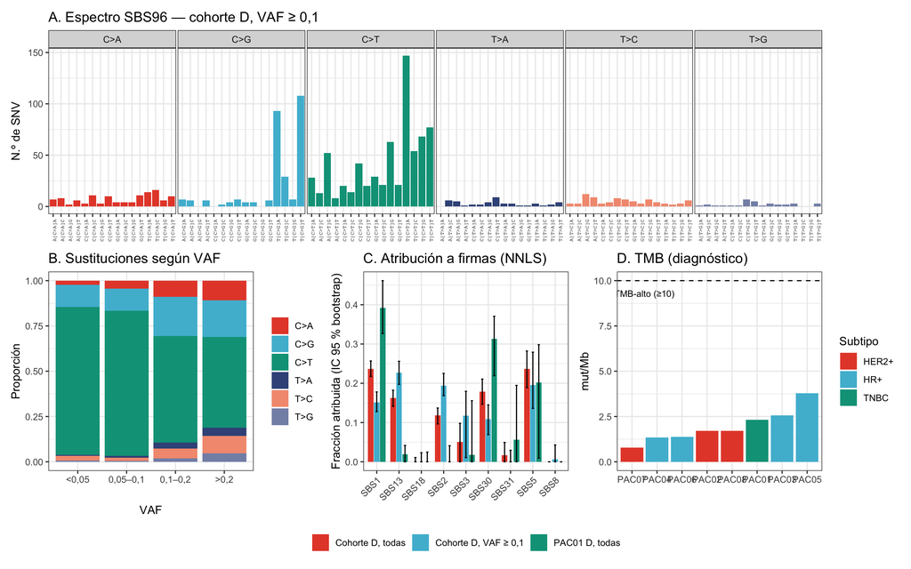

```r
x96 <- contar_sbs96(grupos[[2]]$ref, grupos[[2]]$alt, grupos[[2]]$trinuc, canales)
esp <- data.frame(canal = factor(canales, levels = canales), n = x96, sust = substr(canales, 3, 5))
f3a <- ggplot(esp, aes(canal, n, fill = sust)) + geom_col() + facet_grid(~sust, scales = "free_x", space = "free_x") +
  scale_fill_npg(guide = "none") + labs(x = NULL, y = "N.º de SNV", title = "A. Espectro SBS96 — cohorte D, VAF ≥ 0,1") +
  theme(axis.text.x = element_text(angle = 90, size = 5, family = "mono"), panel.spacing = unit(0.1, "lines"))
f3b <- ggplot(as.data.frame(prop.table(table(snv$rango_vaf, snv$sust), 1)), aes(Var1, Freq, fill = Var2)) +
  geom_col() + scale_fill_npg() + labs(x = "VAF", y = "Proporción", fill = NULL, title = "B. Sustituciones según VAF")
f3c <- ggplot(ajustes, aes(firma, aporte, fill = grupo)) +
  geom_col(position = position_dodge(0.8), width = 0.75) +
  geom_errorbar(aes(ymin = li, ymax = ls), position = position_dodge(0.8), width = 0.3) +
  scale_fill_npg() + labs(x = NULL, y = "Fracción atribuida (IC 95 % bootstrap)", fill = NULL, title = "C. Atribución a firmas (NNLS)") +
  theme(legend.position = "bottom", axis.text.x = element_text(angle = 45, hjust = 1))
f3d <- ggplot(tmb, aes(reorder(paciente, TMB), TMB, fill = subtipo)) + geom_col() +
  geom_hline(yintercept = 10, linetype = 2) + annotate("text", x = 1.5, y = 9.3, label = "TMB-alto (≥10)", size = 3) +
  scale_fill_npg() + labs(x = NULL, y = "mut/Mb", fill = "Subtipo", title = "D. TMB (diagnóstico)")
fig3 <- f3a / (f3b | f3c | f3d) + plot_layout(heights = c(1, 1.2))
fig3
```

```r
ggsave("figuras/Fig3_TMB_espectro_firmas.png", fig3, width = 12, height = 7.5, dpi = 300)
```

> **Pregunta 3.3.** Al filtrar por VAF ≥ 0,1, ¿qué firmas ganan peso? (SBS2/SBS13 = APOBEC; SBS1/SBS5 = “reloj”; SBS3 = déficit de recombinación homóloga; SBS30 se parece al daño por desaminación.) ¿Qué cambia en la interpretación?

> **Pregunta 3.4.** Compara los intervalos de PAC01 (~250 SNV) con los de la cohorte. ¿Podrías afirmar que PAC01 tiene un déficit de recombinación homóloga (SBS3) con estos datos? ¿Qué dato adicional (por ejemplo, WGS, firmas de indels o de reordenamientos, o mutaciones en *BRCA1/2*) lo permitiría?

## 5.4 Número de copias, pureza y CCF

```r
cnv <- read.delim("data/cnv/segmentos_sequenza.tsv")
subset(pt, muestra %in% c("PAC01D", "PAC01M"), c(muestra, pureza_patologia, pureza_sequenza, ploidia_sequenza, pureza_ascat))
```

| muestra | pureza_patologia | pureza_sequenza | ploidia_sequenza | pureza_ascat |
| --- | --- | --- | --- | --- |
| PAC01D | 0.339629 | 0.24 | 2.9 | 1.00 |
| PAC01M | 0.050902 | 0.12 | 1.1 | 0.48 |

```r
## Asignar a cada mutación de D el número de copias de su segmento
c01 <- subset(cnv, paciente == "PAC01" & momento == "D")
idx <- sapply(seq_len(nrow(D)), function(i) {
  w <- which(c01$chrom == D$chrom[i] & c01$inicio <= D$pos[i] & c01$fin >= D$pos[i]); if (length(w)) w[1] else NA })
D$CN_total <- c01$CN_total[idx]; D$CN_mayor <- c01$CN_mayor[idx]; D$CN_menor <- c01$CN_menor[idx]
D$CN_total[is.na(D$CN_total)] <- 2
## Supuestos: pureza de Sequenza; m = 1 copia mutada (salvo indicación); el normal es diploide
p_D <- pt$pureza_sequenza[pt$muestra == "PAC01D"]
D$CCF_m1 <- calcular_ccf(D$vaf, p_D, D$CN_total, m = 1)
## m estimado: n.º de copias mutadas más compatible con la VAF (entre 1 y el CN del alelo mayor)
D$m_est <- pmin(pmax(1, round(D$vaf * (p_D * D$CN_total + 2 * (1 - p_D)) / p_D)), pmax(1, D$CN_mayor, na.rm = TRUE))
D$CCF <- calcular_ccf(D$vaf, p_D, D$CN_total, m = D$m_est)
subset(D, gen %in% c("TP53", "NF1") & impacto %in% c("HIGH", "MODERATE"), c(gen, hgvsp, vaf, CN_total, CN_mayor, CN_menor, CCF_m1, m_est, CCF))
```

|  | gen | hgvsp | vaf | CN_total | CN_mayor | CN_menor | CCF_m1 | m_est | CCF |
| --- | --- | --- | --- | --- | --- | --- | --- | --- | --- |
| 189 | TP53 | p.Val173Met | 0.2530120 | 3 | 3 | 0 | 1.5 | 2 | 1.180723 |
| 195 | NF1 | . | 0.2040816 | 3 | 3 | 0 | 1.5 | 2 | 0.952381 |

```r
mean(D$CCF >= 0.8)   # fracción de mutaciones "clonales" (CCF ≥ 0,8)
```

```
## [1] 0.6177606
```

> **Pregunta 3.5.** En PAC01, *TP53* está en un segmento con CN mayor = 3 y CN menor = 0, es decir, con **pérdida de heterocigosidad (LOH)**. Si todas las copias portan la mutación ($m = 3$), ¿cuál es la CCF? ¿Y con $m = 1$? ¿Qué valor es biológicamente coherente? Repite el cálculo con la pureza patológica: ¿cuán sensible es la CCF a la pureza?

## 5.5 Figura 4 — Perfil de número de copias y CCF

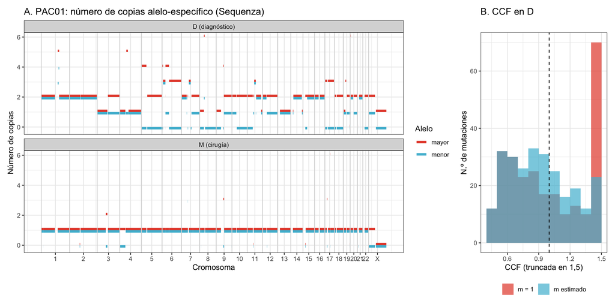

```r
crom <- paste0("chr", c(1:22, "X"))
largo <- tapply(cnv$fin, factor(cnv$chrom, levels = crom), max, na.rm = TRUE)
offset <- setNames(c(0, cumsum(as.numeric(largo))[-length(largo)]), crom)
seg <- subset(cnv, paciente == "PAC01" & chrom %in% crom)
seg$x0 <- seg$inicio + offset[seg$chrom]; seg$x1 <- seg$fin + offset[seg$chrom]
segl <- rbind(transform(seg, cn = CN_mayor, alelo = "mayor"), transform(seg, cn = CN_menor, alelo = "menor"))
segl$momento <- ifelse(segl$momento == "D", "D (diagnóstico)", "M (cirugía)")
f4a <- ggplot(segl) + geom_segment(aes(x = x0, xend = x1, y = cn + ifelse(alelo == "menor", -0.08, 0.08),
                                         yend = cn + ifelse(alelo == "menor", -0.08, 0.08), color = alelo), linewidth = 1.6) +
  geom_vline(xintercept = offset, color = "grey85") + facet_wrap(~momento, ncol = 1) +
  scale_x_continuous(breaks = offset + largo / 2, labels = sub("chr", "", crom)) +
  scale_color_npg() + coord_cartesian(ylim = c(-0.2, 6)) +
  labs(x = "Cromosoma", y = "Número de copias", color = "Alelo", title = "A. PAC01: número de copias alelo-específico (Sequenza)")
ccf_l <- rbind(data.frame(modelo = "m = 1", CCF = D$CCF_m1), data.frame(modelo = "m estimado", CCF = D$CCF))
f4b <- ggplot(ccf_l, aes(CCF, fill = modelo)) + geom_histogram(binwidth = 0.1, boundary = 0, alpha = 0.7, position = "identity") +
  geom_vline(xintercept = 1, linetype = 2) + scale_fill_npg() +
  labs(x = "CCF (truncada en 1,5)", y = "N.º de mutaciones", fill = NULL, title = "B. CCF en D") + theme(legend.position = "bottom")
fig4 <- f4a + f4b + plot_layout(widths = c(3, 1))
fig4
```

```r
ggsave("figuras/Fig4_CNV_CCF_PAC01.png", fig4, width = 12, height = 6, dpi = 300)
```

> **Pregunta 3.6.** ¿Por qué el perfil de M es casi plano (diploide)? ¿Significa que el tumor residual perdió las alteraciones de número de copias?

## 5.6 Variantes estructurales, fusiones y MSI (sin figura)

```r
sv <- read.delim("data/sv_manta_pass.tsv"); fus <- read.delim("data/fusiones_arriba.tsv")
table(sv$muestra, sv$tipo)
```

```
##
##          BND DEL DUP
##   PAC01M   2   0   0
##   PAC02D   8   2   0
##   PAC03D   0   3   1
##   PAC03M   2   0   1
##   PAC04M   2   0   0
##   PAC07D   4   0   5
##   PAC07M   4   1   2
##   PAC08D   0   1   0
##   PAC08M   0   1   1
```

```r
subset(fus, muestra == "PAC01D" & confianza == "high", c(gen1, gen2, tipo, lecturas_split, marco))
```

|  | gen1 | gen2 | tipo | lecturas_split | marco |
| --- | --- | --- | --- | --- | --- |
| 1 | SHROOM3 | GAB2 | translocation | 9 | . |
| 3 | PPIH | CARNMT1-AS1 | translocation/5’-5’ | 3 | out-of-frame |

> **Pregunta 3.7.** El WES captura ~1–2 % del genoma. ¿Por qué Manta detecta tan pocas SV en estos exomas, y qué tecnología usarías para caracterizarlas (WGS, lecturas largas)? Las fusiones de Arriba vienen del **ARN**: ¿qué evidencia mínima pedirías para considerar una fusión real y “accionable” (por ejemplo, *NTRK*)?

> **Pregunta 3.8 (MSI).** En estos datos no se ejecutó ningún algoritmo de MSI (por ejemplo, MSIsensor). ¿Qué esperarías encontrar en un tumor con inestabilidad de microsatélites (dMMR/MSI-H) en cuanto a indels en homopolímeros, TMB y firmas (SBS6/15/26/44)? La MSI es rara en mama (<1–2 %). ¿Qué prueba clínica pedirías (IHQ de MLH1/MSH2/MSH6/PMS2, PCR o NGS)?

# 6 Bloque 4 — Microambiente inmune y repertorio TCR (14 min)

## 6.1 Firmas de expresión

- **CYT (actividad citolítica):** media geométrica de *GZMA* y *PRF1*.
- **IFN-γ (6 genes; Ayers et al., 2017):** media de log2(TPM+1) de *IDO1, CXCL10, CXCL9, HLA-DRA, STAT1, IFNG*.

```r
ex <- read.delim("data/expresion_inmune_tpm.tsv")
ex$muestra <- paste0(ex$paciente, ex$momento)
mat <- with(ex, tapply(TPM, list(gen, muestra), sum))
puntajes <- data.frame(muestra = colnames(mat),
  CYT   = sqrt((mat["GZMA", ] + 1) * (mat["PRF1", ] + 1)) - 1,
  IFNG6 = colMeans(log2(mat[c("IDO1", "CXCL10", "CXCL9", "HLA-DRA", "STAT1", "IFNG"), ] + 1)),
  CD8A  = log2(mat["CD8A", ] + 1), PTPRC = log2(mat["PTPRC", ] + 1),
  EPCAM = log2(mat["EPCAM", ] + 1), COL1A1 = log2(mat["COL1A1", ] + 1))
puntajes$paciente <- substr(puntajes$muestra, 1, 5); puntajes$momento <- substr(puntajes$muestra, 6, 6)
puntajes <- merge(puntajes, clin[, c("paciente", "momento", "subtipo", "respuesta", "sTIL")])
puntajes[, c("muestra", "subtipo", "respuesta", "sTIL", "CYT", "IFNG6", "EPCAM", "COL1A1")]
```

| muestra | subtipo | respuesta | sTIL | CYT | IFNG6 | EPCAM | COL1A1 |
| --- | --- | --- | --- | --- | --- | --- | --- |
| PAC01D | TNBC | Non-responder | 5 | 2.3313961 | 4.426025 | 4.4289463 | 9.250133 |
| PAC01M | TNBC | Non-responder | 2 | 1.2182425 | 2.825399 | 3.0054000 | 8.845145 |
| PAC02D | HER2+ | Responder | 50 | 5.5080335 | 6.086781 | 4.0443941 | 8.868730 |
| PAC02M | HER2+ | Responder | 1 | 0.6278821 | 2.505049 | 0.2986583 | 10.486735 |
| PAC03D | HR+ | Responder | 25 | 2.0135029 | 4.527652 | 4.9749881 | 6.611615 |
| PAC03M | HR+ | Responder | 1 | 0.5066519 | 2.042694 | 1.7355222 | 8.743724 |
| PAC05D | HR+ | Non-responder | 15 | 6.7448176 | 5.091092 | 3.4711875 | 10.291585 |
| PAC05M | HR+ | Non-responder | 5 | 0.6500000 | 2.863866 | 2.4646683 | 10.597568 |
| PAC06D | HR+ | Non-responder | 20 | 1.0024984 | 4.783322 | 3.5298209 | 8.283366 |
| PAC06M | HR+ | Non-responder | 2 | 0.0000000 | 1.417876 | 0.0000000 | 10.591784 |
| PAC07D | HER2+ | Responder | 15 | 1.1126997 | 3.860410 | 3.5885647 | 9.524601 |
| PAC07M | HER2+ | Responder | 1 | 1.4899799 | 3.656129 | 0.8875253 | 10.430348 |

## 6.2 Figura 5 — Firmas inmunes: D vs M, por grupo y heatmap

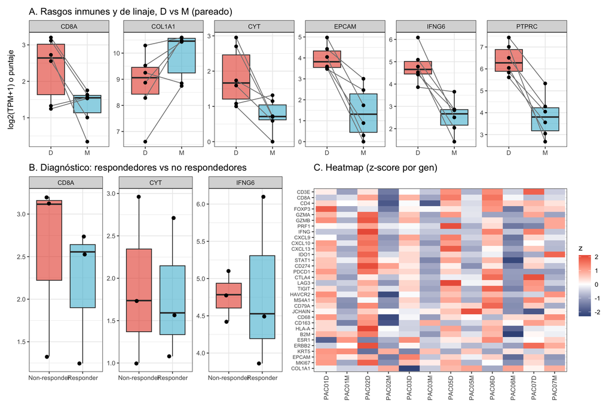

```r
larga <- reshape(puntajes[, c("paciente", "momento", "respuesta", "CYT", "IFNG6", "CD8A", "PTPRC", "EPCAM", "COL1A1")],
                 direction = "long", varying = c("CYT", "IFNG6", "CD8A", "PTPRC", "EPCAM", "COL1A1"),
                 v.names = "valor", timevar = "rasgo", times = c("CYT", "IFNG6", "CD8A", "PTPRC", "EPCAM", "COL1A1"))
larga$valor_log <- ifelse(larga$rasgo == "CYT", log2(larga$valor + 1), larga$valor)
f5a <- ggplot(larga, aes(momento, valor_log, fill = momento)) +
  geom_boxplot(outlier.shape = NA, alpha = 0.6) + geom_line(aes(group = paciente), color = "grey50") +
  geom_point(size = 1.8) + facet_wrap(~rasgo, scales = "free_y", nrow = 1) + scale_fill_npg(guide = "none") +
  labs(x = NULL, y = "log2(TPM+1) o puntaje", title = "A. Rasgos inmunes y de linaje, D vs M (pareado)")
f5b <- ggplot(subset(larga, momento == "D" & rasgo %in% c("CYT", "IFNG6", "CD8A")), aes(respuesta, valor_log, fill = respuesta)) +
  geom_boxplot(outlier.shape = NA, alpha = 0.6) + geom_jitter(width = 0.1, size = 2) +
  facet_wrap(~rasgo, scales = "free_y") + scale_fill_npg(guide = "none") +
  labs(x = NULL, y = NULL, title = "B. Diagnóstico: respondedores vs no respondedores")
genes_hm <- c("CD3E", "CD8A", "CD4", "FOXP3", "GZMA", "GZMB", "PRF1", "IFNG", "CXCL9", "CXCL10", "CXCL13", "IDO1",
              "STAT1", "CD274", "PDCD1", "CTLA4", "LAG3", "TIGIT", "HAVCR2", "MS4A1", "CD79A", "JCHAIN", "CD68", "CD163",
              "HLA-A", "B2M", "ESR1", "ERBB2", "KRT5", "EPCAM", "MKI67", "COL1A1")
z <- t(scale(t(log2(mat[genes_hm, ] + 1))))
hm <- data.frame(gen = factor(rep(rownames(z), ncol(z)), levels = rev(genes_hm)),
                 muestra = rep(colnames(z), each = nrow(z)), z = as.vector(z))
f5c <- ggplot(hm, aes(muestra, gen, fill = pmax(pmin(z, 2.5), -2.5))) + geom_tile() +
  scale_fill_gradient2(low = pal_npg()(4)[4], mid = "white", high = pal_npg()(1), name = "z") +
  labs(x = NULL, y = NULL, title = "C. Heatmap (z-score por gen)") +
  theme(axis.text.x = element_text(angle = 90, vjust = 0.5), axis.text.y = element_text(size = 7))
fig5 <- (f5a) / (f5b | f5c) + plot_layout(heights = c(1, 1.6))
fig5
```

```r
ggsave("figuras/Fig5_firmas_inmunes.png", fig5, width = 12, height = 8, dpi = 300)
```

> **Pregunta 4.1.** La CYT baja de D a M en casi todos los pacientes. ¿Es “inmunosupresión por el tratamiento”? Mira *EPCAM* y *COL1A1*: ¿cómo cambia la **composición** del tejido? ¿Qué método usarías para separar composición de estado celular (deconvolución, scRNA-seq, transcriptómica espacial)?

> **Pregunta 4.2.** Con n = 6 pacientes con ARN, ¿puedes concluir algo sobre respondedores vs no respondedores? ¿Qué tamaño muestral necesitarías?

## 6.3 Repertorio TCRβ

T0 = pretratamiento; T3 = momento de la cirugía. Los repertorios tienen **profundidades muy distintas** (de decenas a miles de moléculas), por lo que la diversidad debe compararse **tras rarefacción**.

```r
arch <- list.files("data/tcr", full.names = TRUE)
tcr <- lapply(arch, read.delim); names(tcr) <- sub("\\.tsv$", "", basename(arch))
met <- data.frame(muestra = names(tcr), t(sapply(tcr, function(x) metricas_tcr(x$conteo))))
met$paciente <- substr(met$muestra, 1, 5); met$tiempo <- sub(".*-", "", met$muestra)
n_min <- 200   # profundidad común de rarefacción (moléculas)
rar <- t(sapply(tcr, function(x) if (sum(x$conteo) >= n_min) rarefaccion_tcr(x$conteo, n_min) else c(clonotipos = NA, shannon = NA, clonalidad = NA)))
met <- cbind(met, setNames(as.data.frame(rar), paste0(colnames(rar), "_rar")))
met[, c("muestra", "lecturas", "clonotipos", "clonalidad", "frac_top10", "clonotipos_rar", "clonalidad_rar")]
```

|  | muestra | lecturas | clonotipos | clonalidad | frac_top10 | clonotipos_rar | clonalidad_rar |
| --- | --- | --- | --- | --- | --- | --- | --- |
| PAC01-T0 | PAC01-T0 | 793 | 202 | 0.0576950 | 0.1664565 | 115.06 | 0.0333262 |
| PAC01-T3 | PAC01-T3 | 800 | 141 | 0.1027747 | 0.3350000 | 87.90 | 0.0725722 |
| PAC02-T0 | PAC02-T0 | 10576 | 2820 | 0.0859589 | 0.0874622 | 175.44 | 0.0122155 |
| PAC03-T0 | PAC03-T0 | 3959 | 1306 | 0.0581917 | 0.0972468 | 173.28 | 0.0133630 |
| PAC03-T3 | PAC03-T3 | 43 | 4 | 0.2385921 | 1.0000000 | NA | NA |
| PAC04-T0 | PAC04-T0 | 233 | 42 | 0.0943991 | 0.5450644 | 40.22 | 0.0877977 |
| PAC05-T0 | PAC05-T0 | 364 | 49 | 0.0863886 | 0.5000000 | 44.42 | 0.0792329 |
| PAC05-T1 | PAC05-T1 | 374 | 65 | 0.0803472 | 0.3930481 | 54.78 | 0.0648675 |
| PAC05-T3 | PAC05-T3 | 224 | 47 | 0.0885892 | 0.5044643 | 45.26 | 0.0841893 |
| PAC06-T0 | PAC06-T0 | 1178 | 331 | 0.0461832 | 0.1035654 | 140.32 | 0.0222354 |
| PAC06-T3 | PAC06-T3 | 86 | 20 | 0.2795342 | 0.8837209 | NA | NA |
| PAC07-T0 | PAC07-T0 | 169 | 57 | 0.0766593 | 0.4201183 | NA | NA |
| PAC07-T3 | PAC07-T3 | 222 | 74 | 0.0742863 | 0.3873874 | 71.06 | 0.0716527 |
| PAC08-T0 | PAC08-T0 | 400 | 90 | 0.0647044 | 0.2925000 | 73.54 | 0.0517757 |

```r
## Solapamiento de clonotipos T0–T3 en PAC01
a <- tcr[["PAC01-T0"]]; b <- tcr[["PAC01-T3"]]
comp <- merge(a, b, by = c("cdr3b", "v", "j"), all = TRUE, suffixes = c("_T0", "_T3")); comp[is.na(comp)] <- 0
c(compartidos = sum(comp$conteo_T0 > 0 & comp$conteo_T3 > 0), solo_T0 = sum(comp$conteo_T3 == 0), solo_T3 = sum(comp$conteo_T0 == 0))
```

```
## compartidos     solo_T0     solo_T3
##           0         202         141
```

## 6.4 Figura 6 — Repertorio TCR

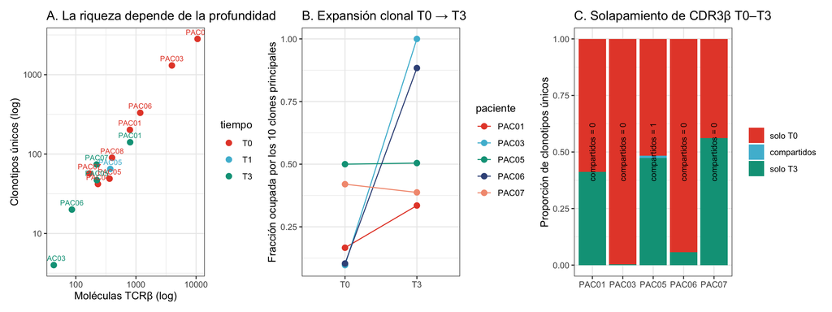

```r
pares <- subset(met, tiempo %in% c("T0", "T3") & paciente %in% names(which(table(met$paciente[met$tiempo %in% c("T0", "T3")]) == 2)))
f6a <- ggplot(met, aes(lecturas, clonotipos, color = tiempo, label = paciente)) + geom_point(size = 2.5) +
  geom_text(vjust = -0.8, size = 2.7, show.legend = FALSE) + scale_x_log10() + scale_y_log10() + scale_color_npg() +
  labs(x = "Moléculas TCRβ (log)", y = "Clonotipos únicos (log)", title = "A. La riqueza depende de la profundidad")
f6b <- ggplot(pares, aes(tiempo, frac_top10, group = paciente, color = paciente)) + geom_line() + geom_point(size = 2.5) +
  scale_color_npg() + labs(x = NULL, y = "Fracción ocupada por los 10 clones principales", title = "B. Expansión clonal T0 → T3")
solap <- do.call(rbind, lapply(unique(pares$paciente), function(p) {
  a <- tcr[[paste0(p, "-T0")]]$cdr3b; b <- tcr[[paste0(p, "-T3")]]$cdr3b
  data.frame(paciente = p, categoria = c("solo T0", "compartidos", "solo T3"),
             n = c(length(setdiff(a, b)), length(intersect(a, b)), length(setdiff(b, a)))) }))
solap$categoria <- factor(solap$categoria, levels = c("solo T0", "compartidos", "solo T3"))
f6c <- ggplot(solap, aes(paciente, n, fill = categoria)) + geom_col(position = "fill") + scale_fill_npg() +
  geom_text(data = subset(solap, categoria == "compartidos"), aes(y = 0.5, label = paste0("compartidos = ", n)), angle = 90, size = 3) +
  labs(x = NULL, y = "Proporción de clonotipos únicos", fill = NULL, title = "C. Solapamiento de CDR3β T0–T3")
fig6 <- f6a + f6b + f6c
fig6
```

```r
ggsave("figuras/Fig6_TCR.png", fig6, width = 12, height = 4.5, dpi = 300)
```

> **Pregunta 4.3.** Casi ningún clonotipo se comparte entre T0 y T3. ¿Es recambio biológico del repertorio o **submuestreo** (cientos de moléculas frente a ~10⁸ clonotipos en una persona)? ¿Cómo lo distinguirías: más profundidad, réplicas técnicas o comparación con sangre? ¿Qué indicaría que los clones dominantes de T3 fueran nuevos o preexistentes? ¿Puedes saber si un clon expandido reconoce un antígeno tumoral? ¿Qué falta: la cadena α, la especificidad, el HLA, datos funcionales?

> **Pregunta 4.4 (BCR).** Estos datos son solo de TCRβ. ¿Qué agregaría el repertorio BCR? Piensa en las estructuras linfoides terciarias, en *CXCL13* y *MS4A1* de la Fig. 5C, y en la hipermutación somática.

# 7 Bloque 5 — Caso integrador y bases de datos (12 min)

## 7.1 Resumen molecular de PAC01

```r
data.frame(
  rasgo = c("Subtipo", "Respuesta (pCR)", "TMB codificante (mut/Mb, D)", "Drivers somáticos", "Número de copias",
            "Persistencia en M", "Espectro (cohorte, VAF ≥ 0,1)", "sTIL D → M", "MSI", "PD-L1"),
  valor = c("Triple negativo", "No (enfermedad residual ~5 %)",
            tmb$TMB[tmb$paciente == "PAC01"],
            paste(unique(subset(D, gen %in% c("TP53", "NF1"))$hgvsp), collapse = "; "),
            "Ploidía ~2,9; LOH de 17p (TP53)", "TP53 con 3 lecturas ALT en M (VAF ~3 %)",
            "APOBEC + reloj; SBS3 incierto", paste(clin$sTIL[clin$paciente == "PAC01"], collapse = " → "),
            "No evaluado", "No disponible"))
```

| rasgo | valor |
| --- | --- |
| Subtipo | Triple negativo |
| Respuesta (pCR) | No (enfermedad residual ~5 %) |
| TMB codificante (mut/Mb, D) | 2.32 |
| Drivers somáticos | p.Val173Met; . |
| Número de copias | Ploidía ~2,9; LOH de 17p (TP53) |
| Persistencia en M | TP53 con 3 lecturas ALT en M (VAF ~3 %) |
| Espectro (cohorte, VAF ≥ 0,1) | APOBEC + reloj; SBS3 incierto |
| sTIL D → M | 5 → 2 |
| MSI | No evaluado |
| PD-L1 | No disponible |

## 7.2 Consultas en bases de datos (en el navegador)

1. **cBioPortal** (https://www.cbioportal.org) → estudio *Breast Invasive Carcinoma (TCGA, PanCancer Atlas)* → consulta `TP53 NF1 PIK3CA`. ¿Con qué frecuencia está mutado *TP53* en los tumores basal-like frente a los luminales? ¿*TP53* V173M es un *hotspot*?
2. **COSMIC** (https://cancer.sanger.ac.uk) → busca *TP53* p.V173M. ¿En cuántas muestras aparece? ¿Qué firmas de referencia tienen las mayores contribuciones en cáncer de mama?
3. **OncoKB** (https://www.oncokb.org) → busca *TP53* y *PIK3CA* H1047R (presente en PAC05). ¿Qué nivel de evidencia terapéutica tiene cada uno, y para qué subtipo y línea de tratamiento?
4. **GDC / TCGA** (https://portal.gdc.cancer.gov) → proyecto TCGA-BRCA. ¿Qué tipos de datos hay (WXS, RNA-seq, metilación), cuáles son de acceso abierto y cuáles controlado, y por qué?

## 7.3 Preguntas de integración

> **5.1 (Observación vs estimación).** Clasifica estas afirmaciones como *observación*, *estimación*, *hipótesis* o *implicación clínica*: (a) “M tiene 142 variantes llamadas”; (b) “TP53 es clonal en D”; (c) “el tumor residual desciende del clon fundador”; (d) “PAC01 podría beneficiarse de inmunoterapia”.

> **5.2 (Biomarcadores de inmunoterapia).** En TNBC temprano de alto riesgo, pembrolizumab neoadyuvante con quimioterapia (KEYNOTE-522) se usa **sin exigir** PD-L1, TMB ni MSI. En TNBC metastásico de primera línea (KEYNOTE-355), se exige **PD-L1 CPS ≥ 10** (22C3). ¿Qué tres biomarcadores evaluarías en PAC01 si recayera, y qué umbral usaría cada uno? ¿Por qué una TMB baja no excluye el beneficio?

> **5.3 (Vacunas de neoantígenos y CAR-T).** Con la TMB de PAC01, ¿cuántos neoantígenos candidatos esperarías, en orden de magnitud? ¿Por qué conviene priorizar mutaciones **clonales** y **persistentes** (como TP53) para una vacuna personalizada? ¿Por qué CAR-T ha funcionado en neoplasias hematológicas (CD19, BCMA) y no aún en cáncer de mama?

> **5.4 (Conclusión y validación).** Redacta en tres líneas una conclusión molecular sobre PAC01 y propón **un** experimento o dato adicional que podría cambiarla (por ejemplo, secuenciación profunda dirigida de M, ctDNA, WGS o la prueba de PD-L1).

# 8 Cierre (3 min)

- Una variante **no llamada** no es una variante **ausente**: la potencia depende de la pureza y de la profundidad.
- Las muestras de baja pureza y FFPE acumulan **artefactos** (C>T de VAF baja); los controles negativos naturales permiten medirlos.
- TMB, CCF y firmas son **estimaciones** que dependen de definiciones y supuestos: decláralos siempre.
- Las firmas inmunes de *bulk* mezclan composición y estado; los repertorios requieren normalizar la profundidad.
- Toda implicación clínica depende del tipo tumoral, el estadio, la línea de tratamiento y el nivel de evidencia.